# Efeito de choque externos sobre o fluxo turístico receptivo internacional no Brasil

## 1 Introdução

Este documento contém uma avaliação dos efeitos de quatro choques exógenos sobre o fluxo turístico receptivo internacional no Brasil.

Os eventos avaliados são:

- Copa do Mundo de Futebol Masculino de 2014;
- Recessão econômica no Brasil de 2015;
- Jogos Olímpicos de 2016;
- Pandemia de covid-19 em 2020.

Pode-se hipotetizar que a recessão de 2015 e a pandemia de covid-19 sejam eventos de impacto negativo, enquanto que os dois mega-eventos esportivos tenham impactos positivos.

Em relação à recessão econômica no Brasil, o Comitê de Datação de Ciclos Econômicos do FGV Ibre[^1] considera que a economia brasileira esteve em fase recessiva do 2º trimestre de 2014 ao 4º trimestre de 2016, período em que foram registradas variações trimestrais negativas no Produto Interno Bruto brasileiro. As maiores variações negativas deste período foram registradas no segundo semestre de 2015 e no primeiro semestre de 2016[^2].

A Organização Mundial da Saúde declarou a pandemia de covid-19 em março de 2020. O término da Emergência de Saúde Pública de Importância Internacional foi declarado pela agência em maio de 2023.[^3]

A proximidade temporal entre os quatro eventos, particularmente entre a Copa do Mundo 2014, a recessão de 2015 e os Jogos Olímpicos de 2016, torna mais adequado analisar os eventos em conjunto, uma vez que é praticamente impossível distinguir os efeitos específicos de cada um deles ao longo do tempo.

## 2 Metodologia

A análise foi realizada usando Interrupted Time Series (ITS), uma técnica de estimação pertencente ao conjunto dos “event-study”, apropriada para analisar séries de dados temporais de somente uma unidade (no caso, o Brasil) e em que há eventos que causam choques nas séries.[^4]

Foram elaboradas estimativas para o fluxo anual e o fluxo mensal, cobrindo o período entre 2009 e 2024.

Os dados anuais do receptivo turístico internacional no Brasil foram examinados em quatro formatos:

1. Volume total de chegadas.
2. Variação anual do volume total de chegadas (isto é, a primeira diferença).
3. Logaritmo natural (log) do volume total de chegadas, que permite interpretar os coeficientes estimados como taxas de variação.
4. Participação (*market-share*) do Brasil no volume turístico internacional.

No entanto, o modelo anual com dados em primeira diferença e o modelo com dados mensais foram descartados por não apresentarem resultados robustos.

Para cada evento, o modelo estima dois coeficientes. O *intercepto* captura a mudança abrupta e permanente no nível das chegadas que se instala a partir do evento — ou seja, o deslocamento imediato da série em relação à trajetória que ela seguia antes. A *inclinação* captura a mudança na taxa de crescimento das chegadas após o evento, indicando se a série passou a crescer mais rápido ou mais lento do que crescia anteriormente. Juntos, os dois coeficientes permitem distinguir entre um efeito pontual, restrito ao período imediato do evento, e um efeito persistente, que altera a trajetória de longo prazo das chegadas.

O modelo buscava estimar coeficientes para o intercepto e a inclinação associados a cada um dos quatro eventos. No entanto, por conta da proximidade temporal entre a recessão de 2015 e os Jogos Olímpicos de 2016, os coeficientes relativos à mudança na inclinação causada por estes dois eventos foi eliminada do modelo, por conta de multicolinearidade. Desta forma, há estimativas de intercepto e inclinação para a Copa e a pandemia, mas para a recessão e os Jogos Olímpicos só há estimativas para o intercepto.

A escolha da matriz de variância-covariância foi orientada pelos diagnósticos específicos de cada modelo. Nos modelos em nível e em log, os erros-padrão foram estimados com correção de Newey-West com defasagem máxima igual a 2, dado que os testes de Breusch-Godfrey indicaram autocorrelação serial até a segunda ordem. Para o modelo de participação, o teste não rejeitou a hipótese nula de ausência de autocorrelação serial ao nível de 5%; por cautela, os erros-padrão foram estimados com matriz HAC geral.

## 3 Fluxo anual, análise agregada, 2009-2024

### 3.1 Chegadas em nível

A observação da série das chegadas turísticas internacionais no Brasil para o período de 2009 a 2024 permite identificar três fases. A primeira delas seria entre 2009 e 2014, com uma sequência de crescimento do volume de chegadas no Brasil. A segunda fase, entre 2015 e 2019 o país apresenta certa estagnação, ainda que batendo os recordes históricos até então. A pandemia de covid-19 marca a terceira fase, com quedra brutal do fluxo em 2020 e 2021, e rápida retomada nos anos seguintes, culminando em novo recorde de chegadas em 2024.

#### 3.1.1 Série

Total de chegadas turísticas internacionais ao Brasil, por ano

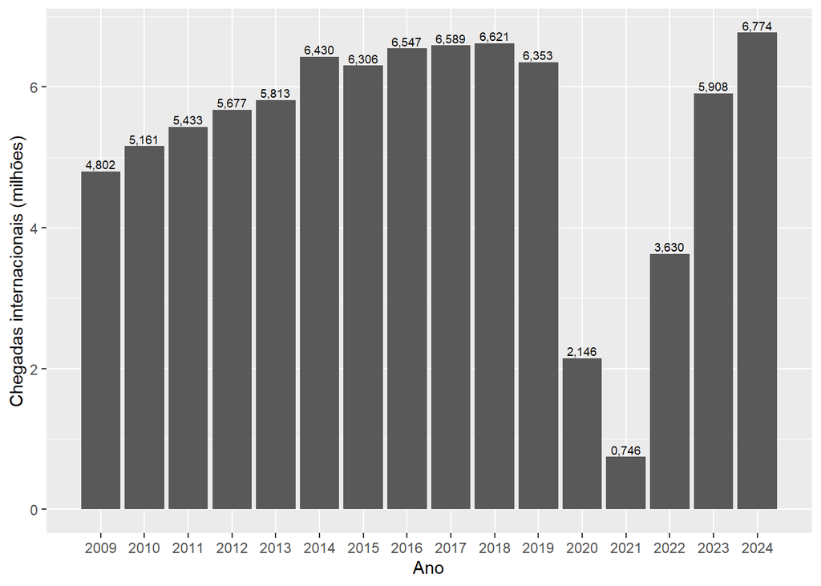

#### 3.1.2 Modelo

O modelo estimado para as chegadas internacionais em nível revela coeficientes estatisticamente significantes para todos os eventos, com exceção da recessão de 2015. O coeficiente associado ao tempo (t) mostra uma tendência de crescimento de aproximadamente 254 mil chegadas por ano.

Para a Copa do Mundo foi identificado um efeito positivo no intercepto e um efeito negativo na inclinação. A estimativa do intercepto é de aproximadamente 600 mil chegadas, o que significa que o evento causou um crescimento do fluxo internacional no Brasil mais de duas vezes superior ao que seria esperado (as 254 mil chegadas estimadas para “t”). Por outro lado, o coeficiente negativo da inclinação revela que após o evento foi registrada uma tendência de queda do volume de chegadas, interrompendo a trajetória de crescimento que se observava desde o início da série. Isso também pode estar atrelado à aproximação da recessão econômica de 2015.

O coeficiente estimado para a recessão é negativo e significante apenas a 10%. Há indícios de perda no volume de chegadas em decorrência da crise econômica, mas não é possível concluir com segurança a respeito.

Os Jogos Olímpicos de 2016 geraram um crescimento de aproximadamente 360 mil chegadas, frente à tendência anterior ao evento. É um efeito positivo, ainda que inferior ao da Copa do Mundo de 2014.

Por fim, o modelo estima que a pandemia de covid-19 representou uma brutal queda do fluxo turístico internacional, da ordem de 6,9 milhões de chegadas. O parâmetro associado à inclinação do evento mostra que após 2020 a série apresentou crescimento de aproximadamente 1,5 milhão de chegadas por ano, vinculada à recuperação acelerada que foi se materializando principalmente de 2022 em diante.

|  | Chegadas em nível |
| --- | --- |
| Tendência linear | 253.771,400*** |
|  | (16.022,060) |
| Copa 2014-intercepto | 599.688,100*** |
|  | (49.023,240) |
| Copa 2014-inclinação | -308.577,300*** |
|  | (34.129,890) |
| Recessão 2015-intercepto | -69.208,100 |
|  | (30.135,410) |
| Rio 2016-intercepto | 358.672,500** |
|  | (74.006,830) |
| Pandemia-intercepto | -6.929.479,000*** |
|  | (790.100,100) |
| Pandemia-inclinação | 1.496.490,000*** |
|  | (200.768,900) |
| Constante | 4.616.113,000*** |
|  | (51.798,610) |
| *Note:* | *p<0,05; **p<0,01;*** p<0,001 |

#### 3.1.3 Visualização

Total de chegadas turísticas internacionais ao Brasil, por ano - dados reais, modelo ajustado e contrafactual

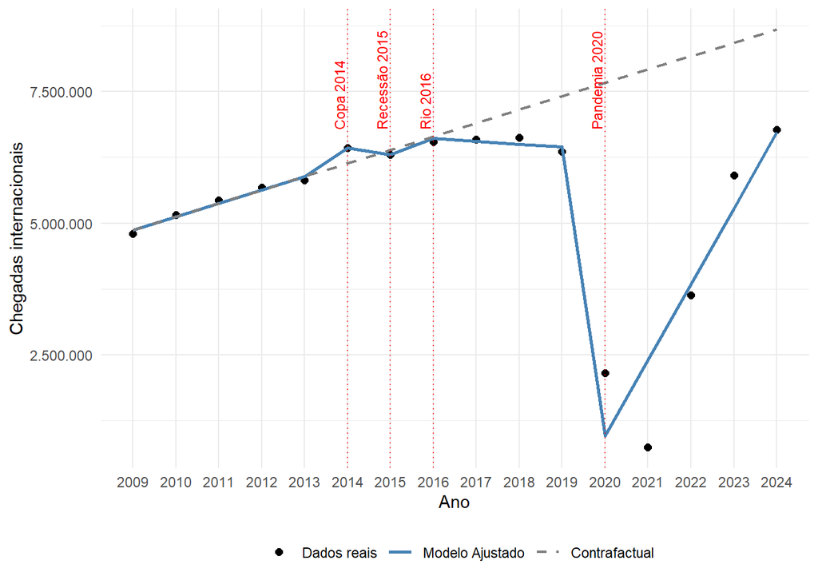

#### 3.1.4 Autocorrelação

O teste Breusch-Godfrey detectou autocorrelação de segunda ordem nos resíduos (LM = 6,28; p = 0,043). A estacionariedade dos resíduos foi confirmada pelo teste ADF (p < 0,01 para k ≤ 1), assegurando a validade assintótica do estimador HAC de Newey-West. Os erros-padrão foram estimados com largura de banda fixada em 2, correspondente à ordem de autocorrelação identificada pelo diagnóstico.

```
    Breusch-Godfrey test for serial correlation of order up to 2

data:  fit_anual_nivel
LM test = 6.2854, df = 2, p-value = 0.04317
```

```
    Augmented Dickey-Fuller Test

data:  residuals(fit_anual_nivel)
Dickey-Fuller = -4.3876, Lag order = 1, p-value = 0.01
alternative hypothesis: stationary
```

```
    Augmented Dickey-Fuller Test

data:  residuals(fit_anual_nivel)
Dickey-Fuller = -5.2768, Lag order = 0, p-value = 0.01
alternative hypothesis: stationary
```

### 3.2 Chegadas em log

#### 3.2.1 Série

Logaritmo natural do total de chegadas turísticas internacionais ao Brasil, por ano

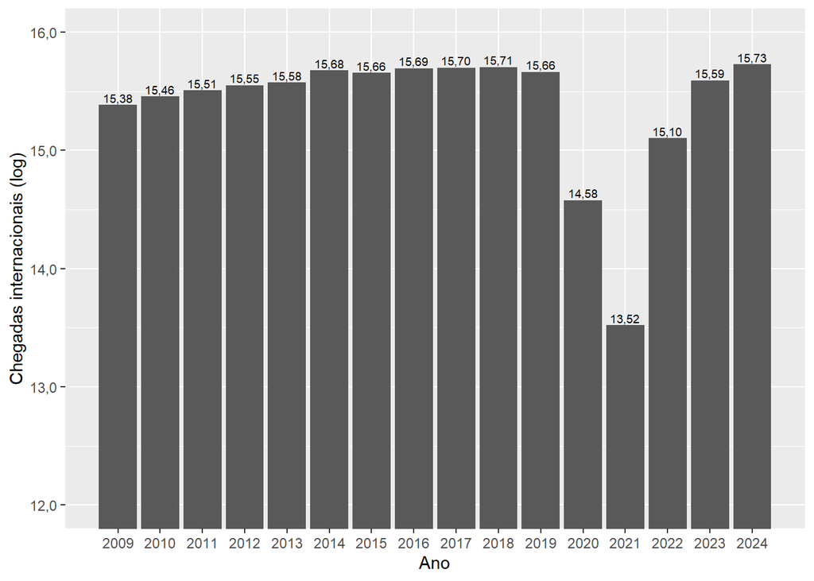

Crescimento das chegadas turísticas internacionais ao Brasil, por ano (%)

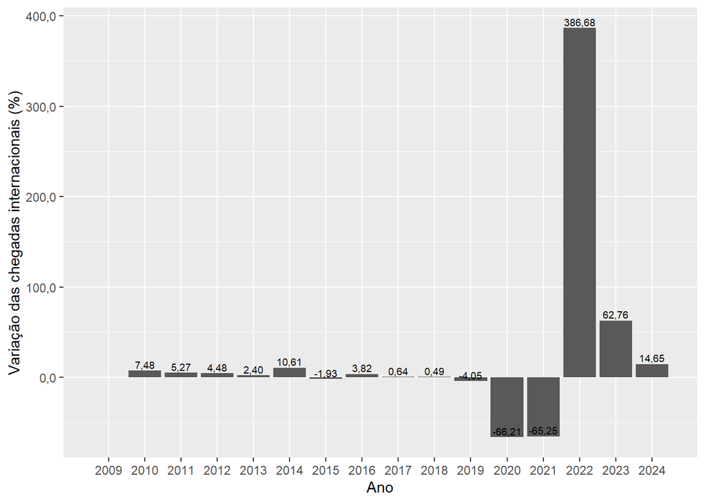

#### 3.2.2 Modelo

O modelo relativo ao logaritmo natural das chegadas turísticas internacionais ao Brasil revela, após conversão dos coeficientes para percentuais, uma tendência linear de crescimento 4,8% antes dos eventos analisados.

Estima-se que em 2014 houve um aumento de cerca de 10% acima da tendência. Após 2014, a tendência caiu 5,4 pontos percentuais ao ano, gerando uma tendência líquida negativa (4,8% - 5,4% = -0,6% ao ano). Isso sugere que a Copa causou um efeito imediato positivo, mas não deixou legado de crescimento.

Os Jogos Olímpicos 2016 mostraram um efeito positivo e significante de 5,8% no ano do evento.

As estimativas relativas à pandemia reforçam o impacto imediato negativo (-87,5%) e a posterior recuperação acelerada (56%).

Os resultados são condizentes com o modelo em nível. Houve leve divergência apenas no que tange à recessão de 2015. Embora os dois modelos estimem efeito negativo, apenas o modelo em log apresentou resultados estatisticamente significantes a 5%.

|  | Chegadas em log |
| --- | --- |
| Tendência linear | 0,048*** |
|  | (0,004) |
| Copa 2014-intercepto | 0,094*** |
|  | (0,010) |
| Copa 2014-inclinação | -0,056*** |
|  | (0,006) |
| Recessão 2015-intercepto | -0,011* |
|  | (0,005) |
| Rio 2016-intercepto | 0,056** |
|  | (0,011) |
| Pandemia-intercepto | -2,084*** |
|  | (0,368) |
| Pandemia-inclinação | 0,445** |
|  | (0,094) |
| Constante | 15,352*** |
|  | (0,012) |
| *Note:* | *p<0,05; **p<0,01;*** p<0,001 |

Coeficientes em log convertidos para percentual:

```
             pct
t            4.9
D_copa       9.9
slope_copa  -5.4
D_rec       -1.1
D_rio        5.8
D_pand     -87.6
slope_pand  56.0
```

#### 3.2.3 Visualização

Logaritmo natural das chegadas turísticas internacionais ao Brasil, por ano - dados reais, modelo ajustado e contrafactual

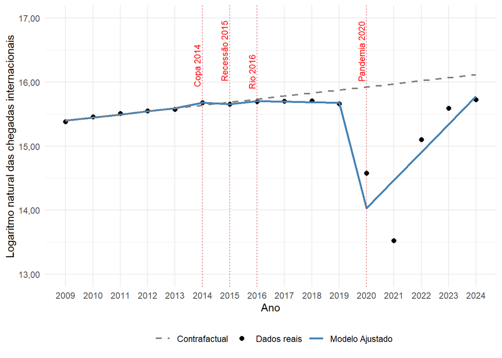

#### 3.2.4 Autocorrelação

O teste Breusch-Godfrey detectou autocorrelação de segunda ordem nos resíduos (LM = 7,32; p = 0,026). A estacionariedade dos resíduos foi confirmada pelo teste ADF (p < 0,01 para k ≤ 1), assegurando a validade assintótica do estimador HAC de Newey-West. Os erros-padrão foram estimados com largura de banda fixada em 2, correspondente à ordem de autocorrelação identificada pelo diagnóstico.

```
    Breusch-Godfrey test for serial correlation of order up to 2

data:  fit_anual_log
LM test = 7.3153, df = 2, p-value = 0.02579
```

```
    Augmented Dickey-Fuller Test

data:  residuals(fit_anual_log)
Dickey-Fuller = -4.7376, Lag order = 1, p-value = 0.01
alternative hypothesis: stationary
```

```
    Augmented Dickey-Fuller Test

data:  residuals(fit_anual_log)
Dickey-Fuller = -6.1712, Lag order = 0, p-value = 0.01
alternative hypothesis: stationary
```

```
t test of coefficients:

              Estimate Std. Error   t value              Pr(>|t|)
(Intercept) 15.3521842  0.0115371 1330.6794 < 0.00000000000000022 ***
t            0.0477347  0.0035259   13.5382           0.000000851 ***
D_copa       0.0941139  0.0095773    9.8268           0.000009670 ***
slope_copa  -0.0562444  0.0058262   -9.6538           0.000011036 ***
D_rec       -0.0109660  0.0046381   -2.3643             0.0456496 *
D_rio        0.0556933  0.0113907    4.8894             0.0012099 **
D_pand      -2.0836875  0.3680771   -5.6610             0.0004753 ***
slope_pand   0.4453119  0.0943387    4.7204             0.0015015 **
---
Signif. codes:  0 '***' 0.001 '**' 0.01 '*' 0.05 '.' 0.1 ' ' 1
```

### 3.3 Participação do Brasil

A cota do Brasil no total de chegadas mundiais se mantinha praticamente estagnada 2010 e 2016. Em 2014 foi obtido o melhor resultado, com 0,56%. Nos três anos anteriores ao início da pandemia de covid-19 o país registrou perdas seguidas de participação, chegando a 0,43% em 2019. Em 2023 e 2024 o país superou a participação que tinha em 2019, mas demonstra dificuldade para retomar o patamar registrado nos anos 2010.

#### 3.3.1 Série

Participação do Brasil no total mundial de chegadas (anual)

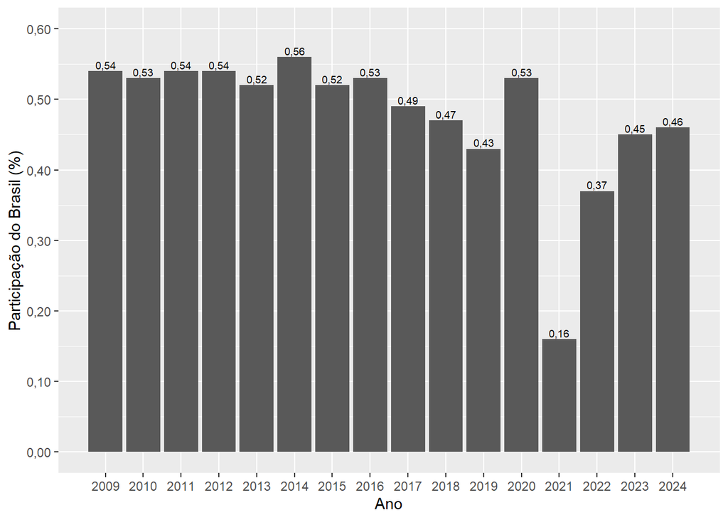

#### 3.3.2 Modelo

O modelo que tem como variável dependente a participação do Brasil no mercado receptivo turístico internacional conduz às mesmas conclusões que os modelos sobre as chegadas em nível e em log.

A tendência linear apresenta coeficiente não significante. Isso sugere que o país seguia a dinâmica do turismo mundial.

O Copa de 2014 significou uma elevação de 0,064 p.p., algo substancial, representando quase 12% de sua média no período (cerca de 0,54%). Contudo, após o evento o país passou a perder participação relativa, com queda de 0,029 p.p./ano (tendência líquida de −0,003 − 0,029 = −0,032 p.p./ano).

Consistente com o modelo em log, a recessão apresentou queda estatisticamente significante na participação do Brasil (−0,008 p.p.).

As Olimpíadas representaram um crescimento de 0,040 p.p. na participação do Brasil no turismo mundial. Assim como nos demais modelos, trata-se de um impacto positivo, embora inferior ao da Copa do Mundo de 2014.

Para este modelo, os resultados relativos à pandemia não são estatisticamente significantes, apesar dos coeficientes com os sinais esperados. Pode-se atribuir tal resultado ao colapso do turismo mundial e também a problemas no registro de chegadas turísticas em diversos países, principalmente em 2020, 2021 e 2022.

|  | Participação no total mundial (p.p.) |
| --- | --- |
| Tendência linear | -0,003 |
|  | (0,002) |
| Copa 2014-intercepto | 0,064*** |
|  | (0,007) |
| Copa 2014-inclinação | -0,029*** |
|  | (0,003) |
| Recessão 2015-intercepto | -0,008*** |
|  | (0,001) |
| Rio 2016-intercepto | 0,040*** |
|  | (0,004) |
| Pandemia-intercepto | -0,083 |
|  | (0,173) |
| Pandemia-inclinação | 0,047 |
|  | (0,041) |
| Constante | 0,543*** |
|  | (0,006) |
| *Note:* | *p<0,05; **p<0,01;*** p<0,001 |

#### 3.3.3 Visualização

Participação do Brasil no total mundial de chegadas, por ano - dados reais x modelo ajustado e contrafactual

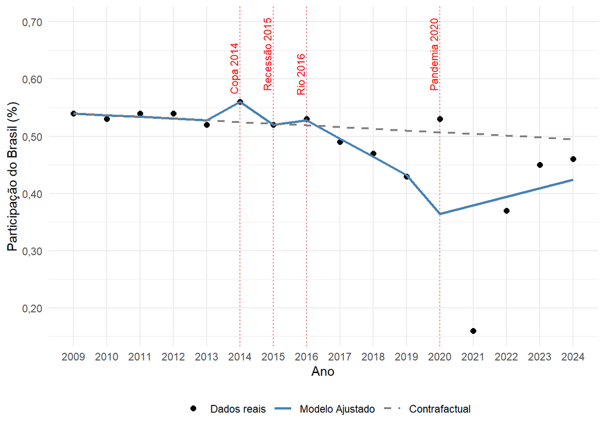

#### 3.3.4 Autocorrelação

O teste Breusch-Godfrey não detectou autocorrelação de segunda ordem nos resíduos (LM = 5,45; p = 0,066).

```
    Breusch-Godfrey test for serial correlation of order up to 2

data:  fit_anual_pct
LM test = 5.4476, df = 2, p-value = 0.06562
```

### 3.4 Resumo

Os modelos mostram:

|  | Chegadas internacionais |  |  |
| --- | --- | --- | --- |
|  | Nível | Log | Participação |
| Tendência linear | 253.771,400*** | 0,048*** | -0,003 |
|  | (16.022,060) | (0,004) | (0,002) |
| Copa 2014-intercepto | 599.688,100*** | 0,094*** | 0,064*** |
|  | (49.023,240) | (0,010) | (0,007) |
| Copa 2014-inclinação | -308.577,300*** | -0,056*** | -0,029*** |
|  | (34.129,890) | (0,006) | (0,003) |
| Recessão 2015-intercepto | -69.208,100 | -0,011* | -0,008*** |
|  | (30.135,410) | (0,005) | (0,001) |
| Rio 2016-intercepto | 358.672,500** | 0,056** | 0,040*** |
|  | (74.006,830) | (0,011) | (0,004) |
| Pandemia-intercepto | -6.929.479,000*** | -2,084*** | -0,083 |
|  | (790.100,100) | (0,368) | (0,173) |
| Pandemia-inclinação | 1.496.490,000*** | 0,445** | 0,047 |
|  | (200.768,900) | (0,094) | (0,041) |
| Constante | 4.616.113,000*** | 15,352*** | 0,543*** |
|  | (51.798,610) | (0,012) | (0,006) |
| *Note:* | *p<0,05; **p<0,01;*** p<0,001 |  |  |

## Notas de rodapé

[^1]: https://portalibre.fgv.br/codace
[^2]: https://www.ipeadata.gov.br/exibeserie.aspx?serid=38414
[^3]: https://www.paho.org/pt/noticias/5-5-2023-oms-declara-fim-da-emergencia-saude-publica-importancia-internacional-referente
[^4]: ver por exemplo: Lopez Bernal, J., Cummins, S., & Gasparrini, A. (2016). Interrupted time series regression for the evaluation of public health interventions: A tutorial. International Journal of Epidemiology, dyw098. https://doi.org/10.1093/ije/dyw098